# 数说风云：中科院近20年院士增选之数据分析

六边形吃瓜群众

2021-11-23

## 概览

最近，中科院院士增选信息刷爆了网络。不少个人、大学、研究院、初高中、省市发布喜讯，光本吃瓜群众的朋友圈就有数十条喜气洋洋的转发。 但这些新闻大都聚焦于个人或某个单位，而本吃瓜群众不仅想看个人八卦，更想看到一个较为全面的统计分析，多次搜索却没有看到。 于是，本吃瓜群众想找相关公开、整理好的数据集来自己分析，但这又一次失败了——呜呼哀哉，原来并没有人分享整理好的数据集！

作为一名写得了爬虫、洗得白数据、画得好图表，还会rmarkdown自动化生成动态文档的六边形吃瓜群众，这些又有何难？ 于是这篇并不那么严谨，且仅为满足本吃瓜群众莫名好奇心的简单粗暴分析报告就诞生了。

我们整理了2000-2021年共11次中科院院士增选信息以及相关单位地址和类型， 从人数、学部、单位、双一流大学、区域、单位类型、年龄等多个角度进行统计、可视化和比较分析。 关于数据集和代码相关更详细的说明，参见文末。

首先，我们先看2000年以来，中科院院士增选的简要数据。 下面的表格支持搜索和按列排序（仅支持HTML电脑端，如果是微信/知乎端，请点击动态报告链接在电脑端交互查看）。

您可以在搜索框输入某所大学、某个专业来查询相关数据。首先，直接可以看到，有584条信息，对应584个增选院士的信息。 搜索“女”，有40条记录，说明新千年后共有40位女性入选。搜索“天体物理”，有8条记录，都是专业为天体物理的。 搜索“香港”，有21条记录，都是香港高校的入选院士信息。按年龄排序，很快会发现最小的是37岁，最大的是75岁。 是不是便捷如Excel？但又不需要打开Excel:)

| 姓名 | 年龄 | 专业 | 工作单位 | 学部 | 年份 |
| --- | --- | --- | --- | --- | --- |
| 陈松蹊 | 59 | 数学地球物理、数学 | 北京大学 | 数学物理学部 | 2021 |
| 封东来 | 48 | 实验凝聚态物理 | 中国科学技术大学 | 数学物理学部 | 2021 |
| 李骏 | 60 | 数学 | 复旦大学 | 数学物理学部 | 2021 |
| 刘仓理 | 59 | 武器物理 | 中国工程物理研究院 | 数学物理学部 | 2021 |
| 马余强 | 56 | 软物质物理 | 南京大学 | 数学物理学部 | 2021 |
| 阮勇斌 | 58 | 基础数学 | 浙江大学 | 数学物理学部 | 2021 |
| 史生才 | 56 | 天体物理 | 中国科学院紫金山天文台 | 数学物理学部 | 2021 |
| 万宝年 | 59 | 磁约束等离子体物理 | 中国科学院合肥物质科学研究院 | 数学物理学部 | 2021 |
| 王玉鹏 | 56 | 凝聚态理论 | 中国科学院物理研究所 | 数学物理学部 | 2021 |
| 夏克青 | 63 | 流体力学 | 南方科技大学 | 数学物理学部 | 2021 |

[output cut: 574 more lines]

## 人数变化

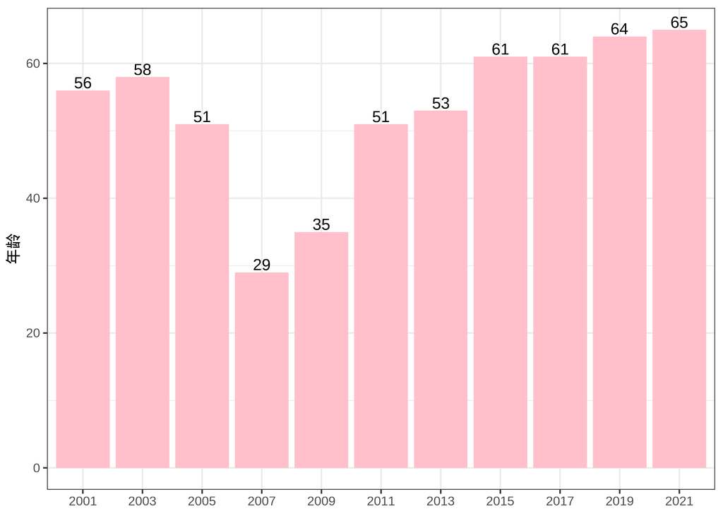

2000年以来中国科学院入选院士总人数为584个，每两年选一次（奇数年），每次人数大都在50~65之间。 但2007、2009这两年出现了断崖式下跌，2007为29人，2009年为35人。我们进一步吃瓜，查阅了当年的新闻。 发现这两年总名额都为60位，但投票规则较以往更为严苛，要求新增选院士获得的赞同票要不少于投票人数的2/3才有当选资格。 要求非常高，竞争很激烈，因此很多名额都落空了。

## 学部分析

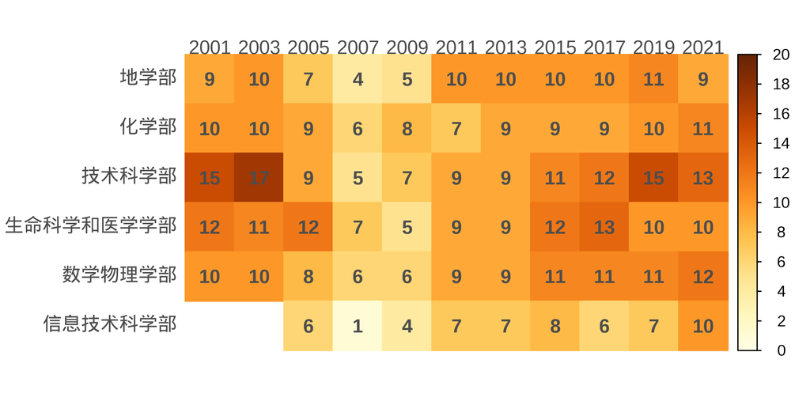

我们再来画折线图来更明显地来看趋势:

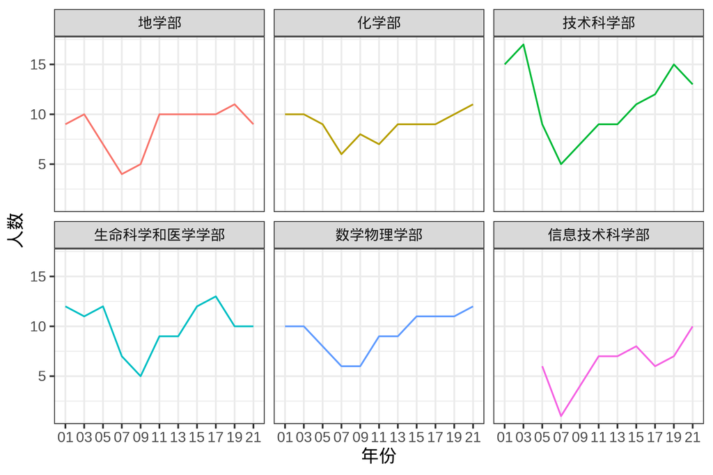

## 单位分析

我们按单位、年份来统计院士增选人，并按照总和从高到低排序。 在搜索框可以搜索相关数据，点击列名可以按高低排序。

|  | 单位 | 01 | 03 | 05 | 07 | 09 | 11 | 13 | 15 | 17 | 19 | 21 | 和 |
| --- | --- | --- | --- | --- | --- | --- | --- | --- | --- | --- | --- | --- | --- |
| 1 | 北京大学 | 5 | 1 | 3 | 2 | 2 | 5 | 5 | 6 | 2 | 5 | 3 | 39 |
| 2 | 清华大学 | 2 | 6 | 1 | 2 | 2 | 3 | 2 | 2 | 4 | 4 | 2 | 30 |
| 3 | 中国科学技术大学 | 1 | 4 | 2 | 1 | 1 | 1 | 2 | 3 | 1 | 4 | 1 | 21 |
| 4 | 南京大学 | 2 | 2 | 4 | 2 |  | 1 | 2 | 1 | 1 |  | 2 | 17 |
| 5 | 复旦大学 |  | 3 | 2 | 1 |  | 2 | 3 |  | 2 | 1 | 1 | 15 |
| 6 | 中国科学院物理研究所 | 2 | 2 | 2 | 1 |  | 2 | 1 | 1 |  | 1 | 1 | 13 |
| 7 | 浙江大学 | 1 | 2 |  |  |  |  |  | 3 | 2 | 1 | 2 | 11 |
| 8 | 中国科学院地质与地球物理研究所 | 1 | 2 | 1 |  | 1 | 1 | 1 | 1 | 1 | 1 | 1 | 11 |
| 9 | 中国科学院上海生命科学研究院 |  | 2 | 3 | 1 | 1 | 1 | 1 | 2 |  |  |  | 11 |
| 10 | 上海交通大学 |  |  | 3 |  |  | 1 |  | 2 | 2 | 1 | 1 | 10 |

[output cut: 190 more lines]

统计数据中可以得出，2000年后有院士入选的一共有200个单位。 我们统计一下这些单位的入选院士人数的分布，发现分布非常不均衡，在200个单位中

- 仅有1人入选的单位多达100个，占比50%
- 1~4人入选的单位170个，占比85%
- 超过（含）5人入选的有30个单位，占比15%
- 超过（含）10人入选的有10个单位，占比5%
- 超过（含）15人入选的有5个单位，占比2.5%
- 超过（含）20人入选的有3个单位，占比1.5%
- 超过（含）30人入选的有2个单位，占比1%

我们把排名前30的单位画出柱状图，来更直观地查看:

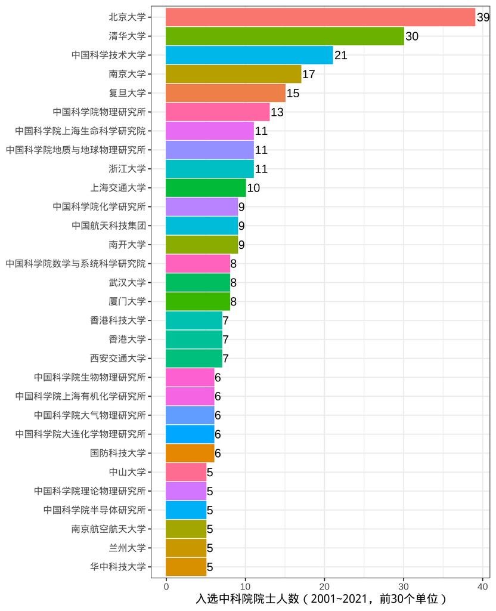

## 双一流大学分析

接下来，我们看看A类一流大学建设高校（共36所）的院士情况，学校名单来自教育部官网。

36所A类一流大学共入选中科院院士242位，占比41%。

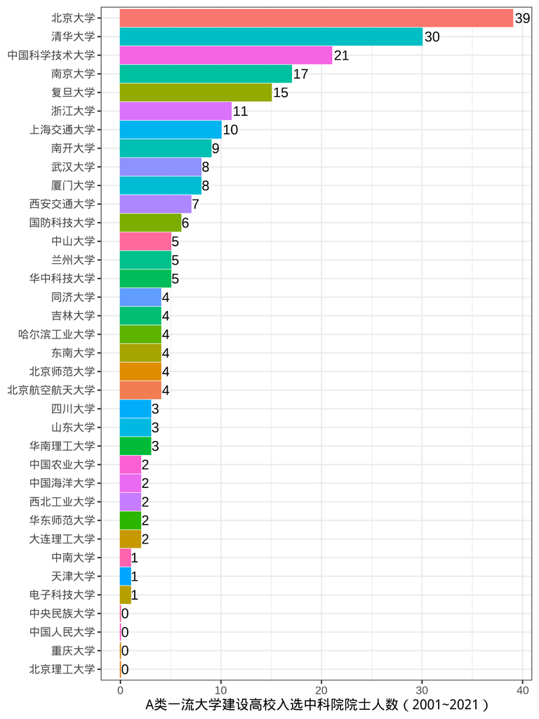

从图中可以得到：

- 有20+个院士入选的高校有3所：北京大学、 清华大学、 中国科学技术大学
- 有10~19个院士入选的高校有4所：南京大学、 复旦大学、 浙江大学、 上海交通大学
- 有5~9个院士入选的高校有8所：南开大学、 厦门大学、 武汉大学、 西安交通大学、 国防科技大学、 华中科技大学、 中山大学、 兰州大学
- 有1~4个院士入选的高校有17所：北京航空航天大学、 北京师范大学、 吉林大学、 哈尔滨工业大学、 同济大学、 东南大学、 山东大学、 华南理工大学、 四川大学、 中国农业大学、 大连理工大学、 华东师范大学、 中国海洋大学、 西北工业大学、 天津大学、 中南大学、 电子科技大学
- 有0个院士入选的高校有4所：中国人民大学、 北京理工大学、 中央民族大学、 重庆大学

## 区域分析

接下来，我们看看各省的院士增选情况。

|  | 省 | 01 | 03 | 05 | 07 | 09 | 11 | 13 | 15 | 17 | 19 | 21 | 和 |
| --- | --- | --- | --- | --- | --- | --- | --- | --- | --- | --- | --- | --- | --- |
| 1 | 北京 | 28 | 27 | 22 | 13 | 17 | 24 | 29 | 30 | 24 | 27 | 26 | 267 |
| 2 | 上海 | 6 | 6 | 11 | 3 | 2 | 4 | 5 | 7 | 9 | 5 | 5 | 63 |
| 3 | 江苏 | 3 | 3 | 5 | 3 |  | 3 | 2 | 3 | 3 | 4 | 7 | 36 |
| 4 | 湖北 | 1 |  | 1 | 1 | 1 | 4 | 2 | 4 | 3 | 3 | 4 | 24 |
| 5 | 安徽 | 1 | 4 | 2 | 1 | 1 | 1 | 2 | 3 | 1 | 5 | 2 | 23 |
| 6 | 香港 | 6 | 4 | 2 |  | 1 | 2 | 1 | 1 | 2 | 2 |  | 21 |
| 7 | 陕西 |  |  | 1 | 1 | 2 | 3 | 2 | 1 | 4 | 2 | 4 | 20 |
| 8 | 广东 | 1 | 1 | 2 |  | 3 | 1 | 1 |  | 4 | 2 | 2 | 17 |
| 9 | 四川 | 1 | 1 | 1 |  | 1 | 2 | 2 |  | 1 | 1 | 3 | 13 |
| 10 | 浙江 | 1 | 2 |  |  |  |  |  | 4 | 2 | 2 | 2 | 13 |

[output cut: 18 more lines]

我们可以看到以下重要信息：

- 北京的入选数独占鳌头，多达267个，占比45.72%
- 上海、江苏、湖北、安徽、香港、陕西均超过了20个
- 内蒙古、 广西、 青海、 宁夏、 澳门、 台湾等6个省级行政区域近20年尚无中新入选科院院士

对所有省级单位的增选总数画出柱状图，来更直观地查看:

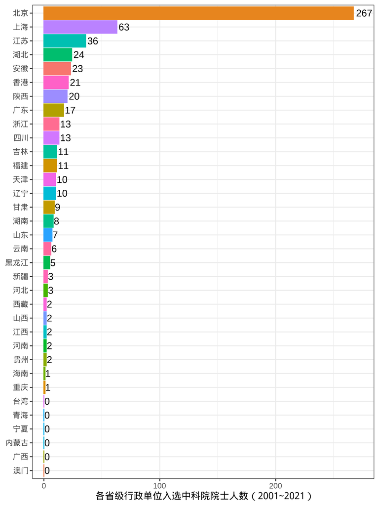

## 单位类型分析

接下来，我们按单位的类型来汇总和查看数据。

|  | 类型 | 01 | 03 | 05 | 07 | 09 | 11 | 13 | 15 | 17 | 19 | 21 | 和 |
| --- | --- | --- | --- | --- | --- | --- | --- | --- | --- | --- | --- | --- | --- |
| 1 | 教育部 | 19 | 20 | 22 | 16 | 13 | 22 | 21 | 25 | 24 | 27 | 29 | 238 |
| 2 | 中国科学院 | 24 | 25 | 22 | 11 | 14 | 19 | 25 | 19 | 23 | 23 | 19 | 224 |
| 3 | 地方院校 | 7 | 6 | 3 | 1 | 3 | 4 | 2 | 2 | 7 | 6 | 4 | 45 |
| 4 | 军事单位 | 2 |  | 1 |  | 2 | 2 | 2 | 4 | 1 | 3 | 6 | 23 |
| 5 | 工信部 | 1 |  | 1 | 1 | 1 | 2 |  | 3 | 3 | 1 | 4 | 17 |
| 6 | 中国航天 | 1 | 3 | 1 |  | 2 |  | 1 | 1 | 1 | 1 | 4 | 15 |
| 7 | 中国工程物理研究院 | 2 |  |  |  |  | 1 |  | 2 |  | 2 | 1 | 8 |
| 8 | 中石油 |  | 1 |  |  |  |  | 1 |  | 2 |  |  | 4 |
| 9 | 卫健委 |  |  |  |  |  | 1 | 1 |  |  | 1 |  | 3 |
| 10 | 地震局 |  | 1 |  |  |  |  | 1 |  |  |  |  | 2 |

[output cut: 10 more lines]

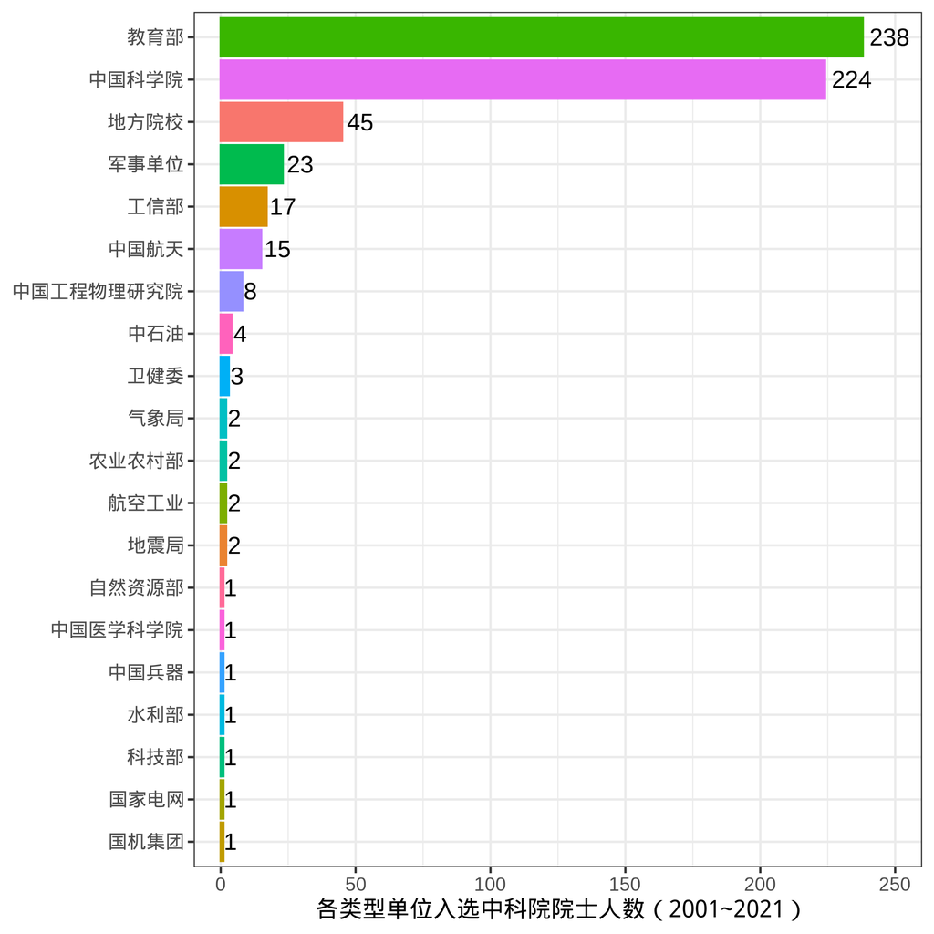

## 年龄变化

最后，我们再来看看年龄变化趋势。

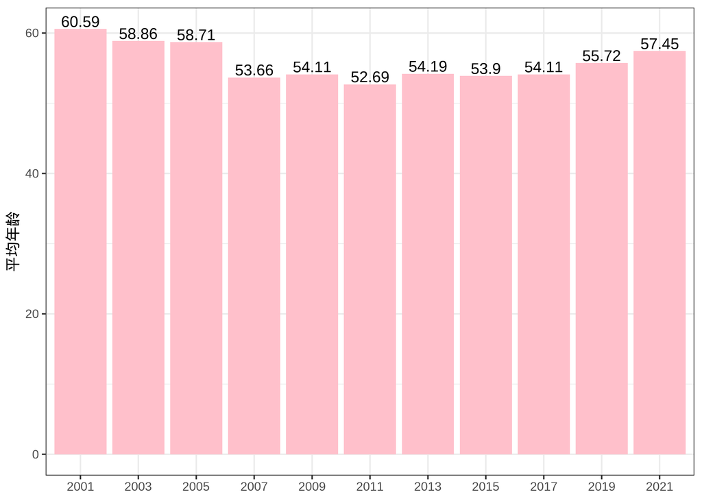

很明显，从2001到2011年间，中科院新入选院士的年龄整体变小，趋势明显。 尤其在2011年，入选年龄算数均值最低，2011年的平均年龄（52.69岁）比2001年（60.59岁）小了将近8岁！ 而此后，年龄总体小幅度上扬，2021年的平均年龄比2011年增加了5岁。背后的机制和原因有待考察。

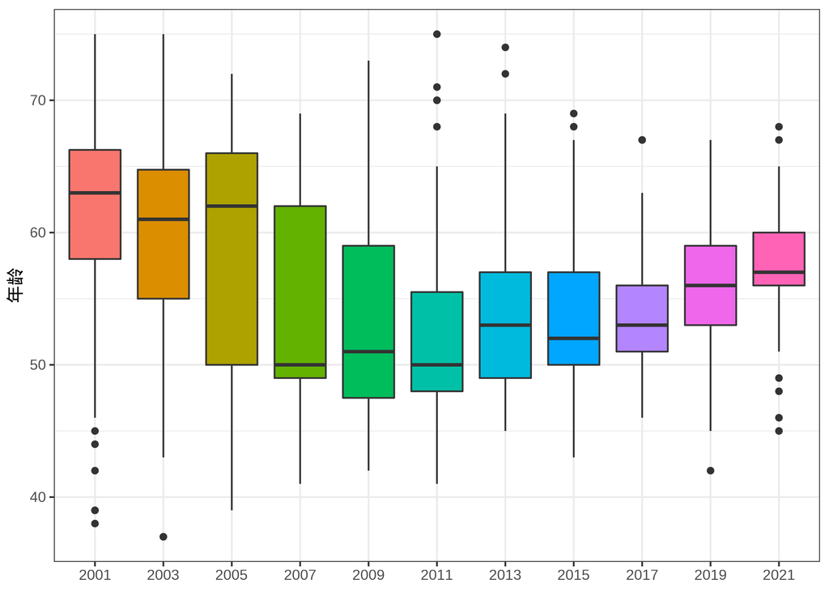

更进一步，我们来看分布的变化。从图中可以看到，40岁以下的离群点有三个，都是在2001和2003年。 年龄最大的是在2011年产生，75岁。 从图中还可以看到，2005、2007、2009年度增选院士的年龄分布比较宽， 此后院士年龄的分布变窄，也就是年龄越来越集中。 在此大胆猜测，院士的年龄，可能也被作为一个重要的考察因素。太大或者太小，概率都会降低。

我们可以绘制箱线图，分学部看看年龄的分布变化：

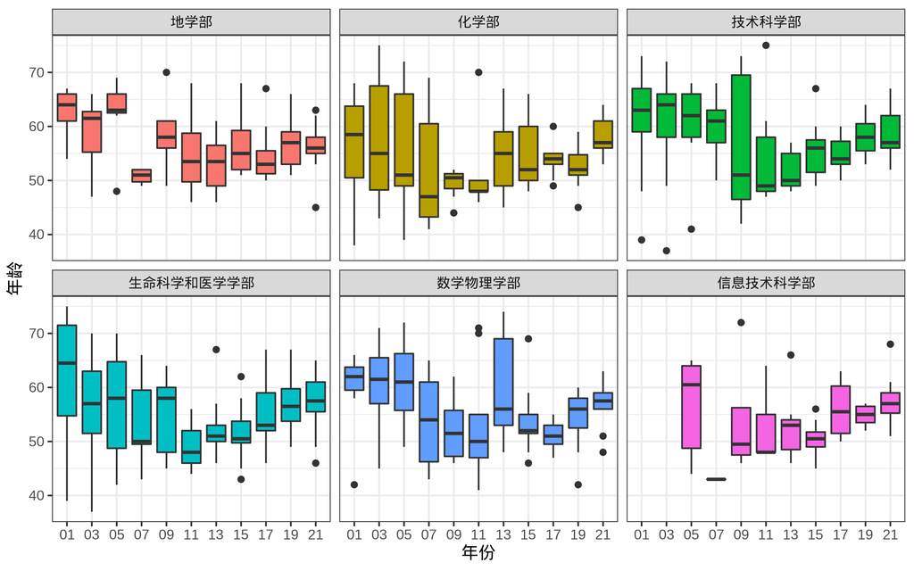

以上，就是本文对中科院2000年以来11次院士增选的初步分析。

鉴于本吃瓜群众不了解相关业务知识，因此仅从数据表现上阐述了一些非常初步的规律。 如果您对数据背后的业务和规律有更多了解，欢迎指正和补充。

## 数据和程序说明

院士增选数据来自于[中科院官网](http://casad.cas.cn/yszx2017/jj/201504/t20150429_4683835.html)， 我们整理了原始数据，经过初步的人工审核，存放在`CAS-Fellow-2001-2021.csv`文件中。 为了分析单位所在的省、市和类型，建立了入选单位的省、市和类型对照数据表，存放在`Empl_location.csv`文件中。 本报告用rmarkdown撰写，相关图表自动生成，得到的HTML文档中的表格支持搜索和交互查询。

还需要特别说明的几点是：

- 同一个单位在不同年份叫法并不统一（比如中科院X所，中国科学院X所），我们对这些单位名称进行了归一
- 生命科学和医学学部之前被称为生物学部，统一为现在的名称：生命科学和医学学部
- 大学的附属医院、国企的下属研究院往上进行了合并，比如复旦大学附属中山医院，合并入复旦大学
- 部分单位在多个地方有分布，在填写所在地的时候，一般以总部为主，比如北京
- 少数院士有两个单位，我们在计算的时候只要单位都在国内，都各算1个
- 部分单位在历史中，发生过组织上的合并和撤销，对这方面不作处理

## 项目地址和版权协议

本文所有的数据、代码都完全公布，报告基于rmarkdown和Git的可重复框架。 读者运行rmd文件即可得到同样的报告，欢迎更多吃瓜群众围观、挑错和协作改进！

本项目相关地址如下，欢迎star、fork、pr三连：

- 动态报告：https://costudy.gitee.io/cas-fellow/
- 项目地址（Gitee）：https://gitee.com/costudy/CAS-fellow/
- 项目地址（Github）：https://github.com/cosname/CAS-fellow/

本项目版权协议使用[木兰宽松许可证第二版](http://license.coscl.org.cn/MulanPSL2)，请遵守相关规定。

引用格式：

> 六边形吃瓜群众，**数说风云：2000-2021年中科院院士增选数据分析**，统计之都，2021，URL：http://costudy.gitee.io/cas-fellow/

## 关于数说风云

【数说风云】是由统计之都发起，针对热点或重大话题，开放式约稿， 以共享数据、传播技术、启发思考、促进创新。欢迎讨论、欢迎参与、欢迎投稿！ 联系邮箱：editor@cosx.org